# Solution

## Problem

Una empresa ha venido desarrollando dos programas de fidelizar a sus consumidores. La división de mercadeo decidió emplear una estrategia en la zona 1 que implicaba un descuento cada vez que se realizaba una compra. Por otro lado, en la zona 2 se decidió implementar un sistema de puntos por cada venta. Puntos que después se podían convertir en productos. Las dos zonas se seleccionaron por dos razones. Primero, las dos zonas geográficas están separadas y ningún cliente de una zona se moviliza a la otra para comprar. Y segundo, las características de los consumidores y las ventas antes de las medidas son muy similares.

La gerencia de mercadeo quiere determinar, empleando solo el criterio de las ventas, cuál delos dos esquemas es mejor. Nuestra tarea es ayudarle a la gerencia de mercadeo a tomar esa decisión. Para tomar dicha decisión se cuenta con las ventas realizadas a mil clientes en cada una de las dos zonas.

¿Cómo tomar la decisión?

## Setup

```r
library(gplots)
library(psych)
library(Rmisc)
```

## Load data

```r
data<-read.csv('data.csv')

head(data)
```

```
##   X      zona1     zona2
## 1 1 1412.94559 1110.2105
## 2 2 1070.83152  704.0232
## 3 3  747.48126 1112.7766
## 4 4   90.32436 1196.4148
## 5 5  564.34615 1010.5796
## 6 6  793.45119 1128.1974
```

```r
dim(data)
```

```
## [1] 1000    3
```

```r
class(data)
```

```
## [1] "data.frame"
```

## Describe data

```r
describe(data[,2:3])
```

```
##       vars    n    mean     sd  median trimmed    mad    min     max
## zona1    1 1000 1040.07 656.63  934.16  967.98 596.05  32.66 5423.79
## zona2    2 1000 1005.09 144.89 1006.29 1006.24 146.14 541.06 1425.96
##         range  skew kurtosis    se
## zona1 5391.13  1.48     4.43 20.76
## zona2  884.90 -0.08    -0.14  4.58
```

```r
summary(data)
```

```
##        X              zona1             zona2
##  Min.   :   1.0   Min.   :  32.66   Min.   : 541.1
##  1st Qu.: 250.8   1st Qu.: 555.47   1st Qu.: 906.4
##  Median : 500.5   Median : 934.16   Median :1006.3
##  Mean   : 500.5   Mean   :1040.07   Mean   :1005.1
##  3rd Qu.: 750.2   3rd Qu.:1352.94   3rd Qu.:1101.9
##  Max.   :1000.0   Max.   :5423.79   Max.   :1426.0
```

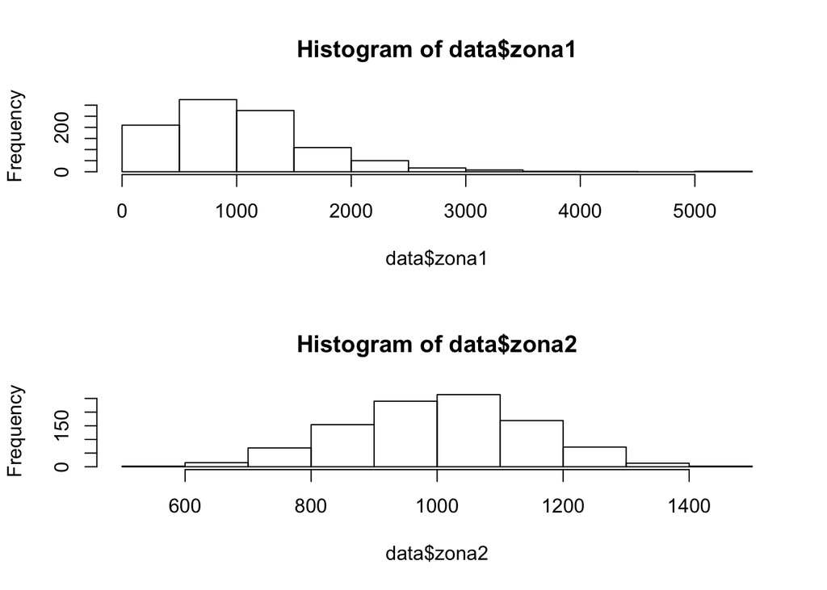

```r
layout(matrix(c(1,2), 2,1, byrow=TRUE))
hist(data$zona1)
hist(data$zona2)
```

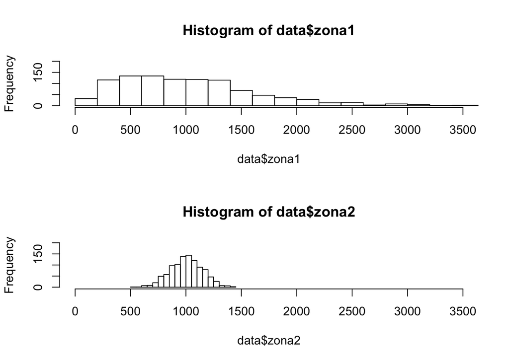

```r
hist(data$zona1, xlim = c(0,3500), ylim = c(0,200), breaks=25)
hist(data$zona2, xlim = c(0,3500), ylim = c(0,200), breaks=25)
```

## Test data

```r
t.test(data$zona1)
```

```
##
##  One Sample t-test
##
## data:  data$zona1
## t = 50.089, df = 999, p-value < 2.2e-16
## alternative hypothesis: true mean is not equal to 0
## 95 percent confidence interval:
##   999.3226 1080.8171
## sample estimates:
## mean of x
##   1040.07
```

```r
t.test(data$zona1, conf.level = 0.99)$conf.int
```

```
## [1]  986.4813 1093.6583
## attr(,"conf.level")
## [1] 0.99
```

```r
t.test(data$zona2)
```

```
##
##  One Sample t-test
##
## data:  data$zona2
## t = 219.37, df = 999, p-value < 2.2e-16
## alternative hypothesis: true mean is not equal to 0
## 95 percent confidence interval:
##   996.0985 1014.0802
## sample estimates:
## mean of x
##  1005.089
```

```r
t.test(data$zona2, conf.level = 0.99)$conf.int
```

```
## [1]  993.2651 1016.9136
## attr(,"conf.level")
## [1] 0.99
```

```r
CI(data$zona1)
```

```
##     upper      mean     lower
## 1080.8171 1040.0698  999.3226
```

```r
CI(data$zona2)
```

```
##     upper      mean     lower
## 1014.0802 1005.0893  996.0985
```

## ANOVA

### Transform

```r
zona <-rep(c("zona1", "zona2"), each = 1000)
ventas <- c(data$zona1, data$zona2)
data1<-as.data.frame(cbind(zona, ventas))
data1[990:1010,]
```

```
##       zona           ventas
## 990  zona1  621.64237834793
## 991  zona1  301.33210377253
## 992  zona1 335.963730430353
## 993  zona1 2180.73756869361
## 994  zona1 868.064507818799
## 995  zona1 335.551150435807
## 996  zona1 703.382146019192
## 997  zona1  502.97342344887
## 998  zona1 1908.27350531207
## 999  zona1 1456.80319595468
## 1000 zona1 990.822534897321
## 1001 zona2 1110.21051353829
## 1002 zona2 704.023173972711
## 1003 zona2 1112.77657776226
## 1004 zona2 1196.41476484728
## 1005 zona2  1010.5795671773
## 1006 zona2 1128.19741411497
## 1007 zona2 1148.77488273005
## 1008 zona2 1097.71428469726
## 1009 zona2 882.552585153611
## 1010 zona2 1116.48414522012
```

```r
class(data1)
```

```
## [1] "data.frame"
```

### Check data

```r
class(data1$zona)
```

```
## [1] "factor"
```

```r
class(data1$ventas)
```

```
## [1] "factor"
```

### Fix data type

```r
data1$ventas <- as.numeric(data1$ventas)
class(data1$ventas)
```

```
## [1] "numeric"
```

### Build table

```r
fit <- aov(ventas ~ zona, data=data1)
summary(fit)
```

```
##               Df    Sum Sq Mean Sq F value Pr(>F)
## zona           1    432356  432356   1.297  0.255
## Residuals   1998 666234144  333451
```

```r
print(fit)
```

```
## Call:
##    aov(formula = ventas ~ zona, data = data1)
##
## Terms:
##                      zona Residuals
## Sum of Squares     432356 666234144
## Deg. of Freedom         1      1998
##
## Residual standard error: 577.4517
## Estimated effects may be unbalanced
```